# Classification Project

David Graber

November 26, 2016

## Abstract

This project’s objective is the correct classificatino of barbell lift exercises into categories according to sensor data gathered by wearable accelerometer-equipped devices on the belt, forearm, arm, and dumbell. The exercises were performed in five different ways, with the first (“A”) being the correct form, and the other ways representing common mistakes.

- (Class A): exactly according to the specification,
- (Class B): throwing the elbows to the front,
- (Class C): lifting the dumbbell only halfway,
- (Class D): lowering the dumbbell only halfway
- (Class E): throwing the hips to the front

Data download and more info: http://groupware.les.inf.puc-rio.br/har

To accomplish this classification I trained a Random Forest model using R’s “caret” package. The resulting model has an estimated out-of-sample accuracy of over 99%.

## Procedure

Initial setup: libraries

```r
library(AppliedPredictiveModeling)
library(caret)
library(gbm)
library(parallel)
library(doParallel)
```

Data import

```r
training1 <- read.csv("C:/Users/dagra/Desktop/DataScience/8MachineLearn/pml-training.csv")
testing1 <- read.csv("C:/Users/dagra/Desktop/DataScience/8MachineLearn/pml-testing.csv")
training1$classe <- as.factor(training1$classe)
```

The training dataset consists of 19622 observations of 160 variables. An initial examination of the dataset reveals several columns of variables that are administrative, indicating times, users, and other information not related to the sensor inputs. I created subsets of the datasets with these columns removed. Many of the entries also contain NA values. Because the model training routines respond differently to NAs, and some will not work at all, I replaced all NA values with 0. There are also several columns that were entered as factors, sometimes with hundreds of levels; these factor columns were dropped as well.

Here I subset the data, removing “X”, “user_name”, “raw_timestamp_part_1”, “raw_timestamp_part_2”, “cvtd_timestamp”, “new_window”, and “num_window”. Also replacing all “NA” with “0”.

```r
drops <- c("X", "user_name", "raw_timestamp_part_1", "raw_timestamp_part_2", "cvtd_timestamp", "new_window", "num_window")
training <- training1[, !(names(training1) %in% drops) ]
training[is.na(training)] <- 0
trainvars <- training[, sapply(training, is.numeric)]
traincor <- trainvars

testing <- testing1[, !(names(testing1) %in% drops) ]
testing[is.na(testing)] <- 0
```

### Model Training

Because Random Forest (“rf”) models are computationally intensive, I made use of the “doParallel” library to run the training on multiple CPU cores. Using the trainControl parameter, I instructed the train method to perform 10-fold cross validation.

```r
trainvars$classe <- training$classe
train_control<- trainControl(method="cv", number=10, savePredictions = TRUE, allowParallel = TRUE)

cl <- makeCluster(6)
registerDoParallel(cl)
modelRF<- train(classe ~ ., data=trainvars, trControl=train_control, method="rf")
stopCluster(cl)
```

### Variable Importance and Estimated Accuracy

```r
# estimate variable importance
importance <- varImp(modelRF, scale=TRUE)
importance
```

```
## rf variable importance
##
##   only 20 most important variables shown (out of 119)
##
##                      Overall
## roll_belt             100.00
## pitch_forearm          59.27
## yaw_belt               57.67
## pitch_belt             46.35
## magnet_dumbbell_z      45.08
## magnet_dumbbell_y      45.02
## roll_forearm           44.64
## accel_dumbbell_y       23.99
## accel_forearm_x        18.89
## magnet_dumbbell_x      18.72
## roll_dumbbell          18.06
## accel_belt_z           17.27
## magnet_belt_z          16.53
## magnet_forearm_z       15.84
## accel_dumbbell_z       15.00
## total_accel_dumbbell   14.68
## magnet_belt_y          13.68
## yaw_arm                12.86
## gyros_belt_z           12.74
## magnet_belt_x          11.05
```

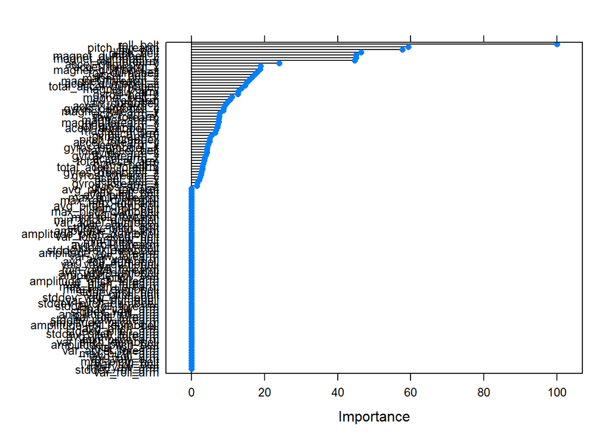

```r
# plot importance
plot(importance)
```

Examining the variables with the highest importance scores provides some intuition about how the algorithm classifies the barbell lifts. Roll, Yaw, and Pitch of the belt sensor are all in the top 4 of the importance list, which makes sense for detecting incorrect hip movements (Class E), and arm movements that would affect balance (requiring hip movement to compensate). Forearm pitch, the 2nd most importance variable, makes perfect sense as a signal of incorrect lifting (classes C and D).

```r
# check accuracy of K-fold validations
modelRF$resample
```

```
##     Accuracy     Kappa Resample
## 1  0.9974516 0.9967765   Fold02
## 2  0.9949032 0.9935531   Fold01
## 3  0.9959225 0.9948425   Fold04
## 4  0.9959225 0.9948427   Fold03
## 5  0.9954152 0.9942000   Fold06
## 6  0.9943935 0.9929070   Fold05
## 7  0.9938869 0.9922676   Fold08
## 8  0.9954128 0.9941966   Fold07
## 9  0.9933707 0.9916119   Fold10
## 10 0.9964340 0.9954900   Fold09
```

```r
mean(modelRF$resample$Accuracy)
```

```
## [1] 0.9953113
```

The model training employed 10-fold cross validation, and the resample statistics provide an estimate of out-of-sample accuracy. The mean accuracy across the 10 validations was: 0.9953113.

### Testing set predictions:

```r
qRF <- predict(modelRF, testing)
names(qRF) <- 1:20
qRF
```

```
##  1  2  3  4  5  6  7  8  9 10 11 12 13 14 15 16 17 18 19 20
##  B  A  B  A  A  E  D  B  A  A  B  C  B  A  E  E  A  B  B  B
## Levels: A B C D E
```

## Appendix: Correlated Variables

Find highly correlated variables:

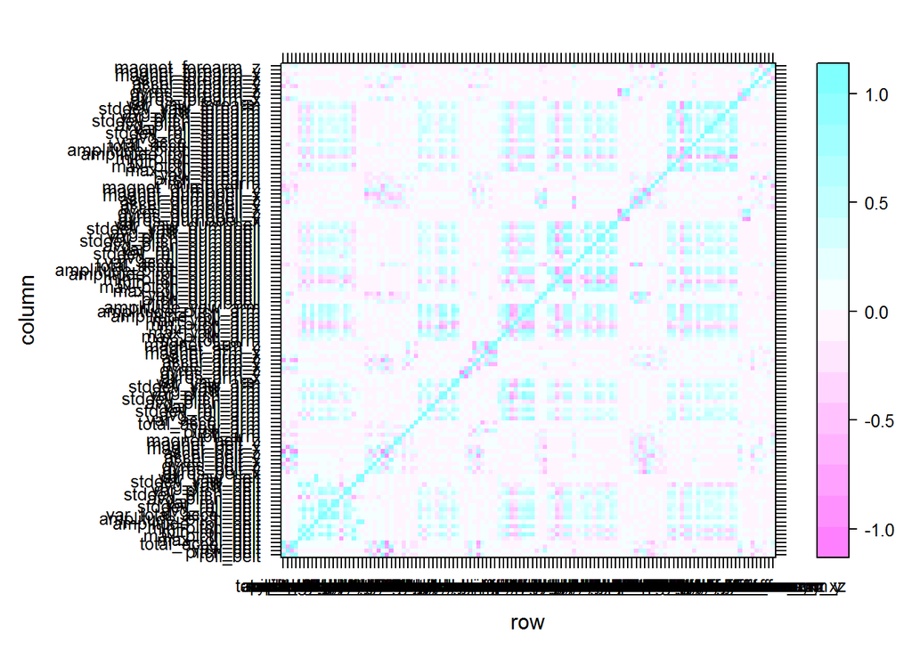

```r
correlationMatrix <- cor(x = traincor, use = "pairwise.complete.obs")
# find attributes that are highly corrected
highlyCorrelated <- findCorrelation(correlationMatrix, cutoff=0.5)
# summarize the correlation matrix
levelplot(correlationMatrix)
```

According to the correlation matrix, there are 81 highly correlated (>0.5) variables in the dataset. Eliminating these variables could speed up the model training process.

## Appendix: Rejected Models

#### LDA

Linear Discriminant Analysis (LDA) models are computationally much faster than Random Forest models, but here I demonstrate that they are much less accurate.

```r
cl <- makeCluster(4)
registerDoParallel(cl)
train_control <- trainControl(method="cv", number=10, savePredictions = TRUE, allowParallel = TRUE)
modelLDA <- train(classe ~ ., data=trainvars, trControl=train_control, method="lda")
stopCluster(cl)

modelLDA$resample
```

```
##     Accuracy     Kappa Resample
## 1  0.7084608 0.6313791   Fold01
## 2  0.7223637 0.6488765   Fold02
## 3  0.7088220 0.6314641   Fold03
## 4  0.6833248 0.5992070   Fold04
## 5  0.6979114 0.6177880   Fold05
## 6  0.6885831 0.6056241   Fold06
## 7  0.7227319 0.6490538   Fold07
## 8  0.6952090 0.6139300   Fold08
## 9  0.6901121 0.6075737   Fold09
## 10 0.7036660 0.6248803   Fold10
```

The mean accuracy during validation of 0.7021185 is significantly lower than the accuracy of the RF model, and would not be effective at passing the quiz in this project!

#### GBM

Generalized Boosted Regression Models (GBM) are more computationally demanding than LDA models, and more accurate in this case, but not as accurate as the RF model.

```r
cl <- makeCluster(6)
registerDoParallel(cl)
train_control <- trainControl(method="cv", number=10, savePredictions = TRUE, allowParallel = TRUE)
modelGBM <- train(classe ~ ., data=trainvars, trControl=train_control, method="gbm")
stopCluster(cl)

modelGBM$resample
```

```
##     Accuracy     Kappa Resample
## 1  0.9643403 0.9548650   Fold06
## 2  0.9622642 0.9522643   Fold09
## 3  0.9658686 0.9568225   Fold05
## 4  0.9617737 0.9516465   Fold08
## 5  0.9648497 0.9555637   Fold02
## 6  0.9607543 0.9503444   Fold04
## 7  0.9638124 0.9542087   Fold07
## 8  0.9612837 0.9510145   Fold10
## 9  0.9602041 0.9496296   Fold01
## 10 0.9658686 0.9568313   Fold03
```

#### Model Comparisons

The mean accuracies of the models are as follows:

- RF: 0.9953113, 0.9940688, rf
- GBM: 0.963102, 0.9533191, gbm
- LDA: 0.7021185, 0.6229777, lda

Variation in Quiz Predictions:

- RF model: B, A, B, A, A, E, D, B, A, A, B, C, B, A, E, E, A, B, B, B
- GBM model: B, A, B, A, A, E, D, B, A, A, B, C, B, A, E, E, A, B, B, B
- LDA model: B, A, B, C, C, E, D, D, A, A, D, A, B, A, E, A, A, B, B, B